# MEDIDAS DE LOCALIZACION

Laura Rodriguez & Valeria Soto

6/2/2020

```r
summary(cars)
```

```
##      speed           dist
##  Min.   : 4.0   Min.   :  2.00
##  1st Qu.:12.0   1st Qu.: 26.00
##  Median :15.0   Median : 36.00
##  Mean   :15.4   Mean   : 42.98
##  3rd Qu.:19.0   3rd Qu.: 56.00
##  Max.   :25.0   Max.   :120.00
```

```r
library(readxl)
exportacionescol = read_excel("F:/ECONOMETRIA FINANCIERA/balanza.xlsx")
```

```r
EX = exportacionescol$expocol
Fecha = as.Date(exportacionescol$fecha,format = "%Y-%m-%d")
BC = exportacionescol$balanza
```

# Percentiles

Los percentiles son aquellos valores de la variable que dividen la distribucion en 100 partes iguales. Cada percentil acumula un 1% de la frecuencia relativa acumulada.

Ejercicio Hallar los percentiles de las exportaciones de Colombia

```r
PERCENTIL_20<-quantile(EX, probs = 0.20)
PERCENTIL_20
```

```
##     20%
## 5486.84
```

```r
EXTREMOSAL_5<-quantile(EX, probs = c(0.05,0.95))
EXTREMOSAL_5
```

```
##       5%      95%
##  3093.56 57106.08
```

# Deciles

Los percentiles son aquellos valores de la variable que dividen la distribucion en 10 partes iguales. Cada percentil acumula un 10% de la frecuencia relativa acumulada.

```r
DECILES<-quantile(EX, probs = c(0.10,0.20,0.30,0.40,0.50,0.60,0.70,0.80,0.90))
DECILES
```

```
##       10%       20%       30%       40%       50%       60%       70%       80%
##  3538.137  5486.840  7121.217 10691.176 11975.424 16062.342 31172.700 36376.840
##       90%
## 44495.173
```

# Cuartiles

Son medidas de ubicacion que se denotan por Q1, Q2 y Q3, y dividen un conjunto de datos ordenado en cuatro partes iguales, con aproximadamente el 25% de los valores en cada grupo.

Con el ejercicio de las exportaciones de Colombia:

```r
CUARTILES<-quantile(EX,probs = c(0.25,0.75))
CUARTILES
```

```
##       25%       75%
##  6837.335 34431.924
```

En este ejemplo se calcularon el primer y el tercer cuartil.

# Diagrama de caja

Es una grafica que se utiliza para mostrar datos atipícos en el conjuntos de datos: * Maximo {Minimo, LI} * Q1 * Mediana * Q3 * Minimo {Maximo, LS} Donde: - LI: Q1-1.5(Q3-Q1) - LS: Q3+1.5(Q3-Q1)

Este se utiliza para mostrar la tendencia y la dispersion de los datos.

Con el ejemplo de las exportaciones de Colombia, se procede a construir el diagrama de caja y bigotes:

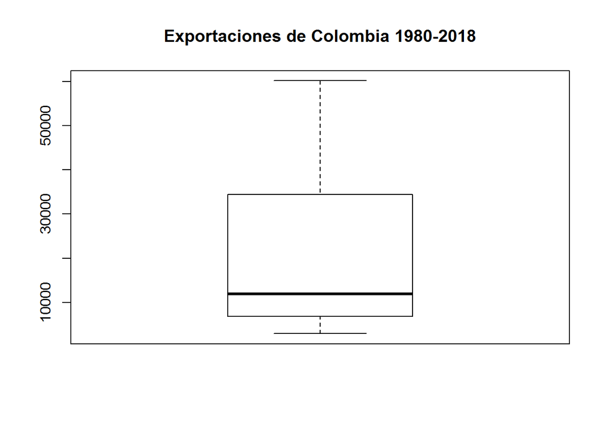

```r
boxplot(EX, main="Exportaciones de Colombia 1980-2018")
```